```python
# This Python 3 environment comes with many helpful analytics libraries installed
# It is defined by the kaggle/python Docker image: https://github.com/kaggle/docker-python
# For example, here's several helpful packages to load

import numpy as np # linear algebra
import pandas as pd # data processing, CSV file I/O (e.g. pd.read_csv)

# Input data files are available in the read-only "../input/" directory
# For example, running this (by clicking run or pressing Shift+Enter) will list all files under the input directory

import os
for dirname, _, filenames in os.walk('/kaggle/input'):
    for filename in filenames:
        print(os.path.join(dirname, filename))

# You can write up to 20GB to the current directory (/kaggle/working/) that gets preserved as output when you create a version using "Save & Run All"
# You can also write temporary files to /kaggle/temp/, but they won't be saved outside of the current session
```

```python
import pandas as pd
import numpy as np
import matplotlib.pyplot as plt
import seaborn as sns
from sklearn.model_selection import train_test_split
from sklearn.linear_model import LinearRegression
from sklearn.metrics import mean_squared_error
from sklearn.neighbors import KNeighborsRegressor
from sklearn.preprocessing import LabelEncoder
from sklearn.preprocessing import StandardScaler
from sklearn.ensemble import RandomForestRegressor
from sklearn.impute import SimpleImputer
```

```python
#load data
train_data = pd.read_csv('./train.csv')
test_data = pd.read_csv('./test.csv')
```

# 1. Overall compare train and test data

```python
train_data.head()
```

|  | Id | MSSubClass | MSZoning | LotFrontage | LotArea | Street | Alley | LotShape | LandContour | Utilities | ... | PoolArea | PoolQC | Fence | MiscFeature | MiscVal | MoSold | YrSold | SaleType | SaleCondition | SalePrice |
| --- | --- | --- | --- | --- | --- | --- | --- | --- | --- | --- | --- | --- | --- | --- | --- | --- | --- | --- | --- | --- | --- |
| 0 | 1 | 60 | RL | 65.0 | 8450 | Pave | NaN | Reg | Lvl | AllPub | ... | 0 | NaN | NaN | NaN | 0 | 2 | 2008 | WD | Normal | 208500 |
| 1 | 2 | 20 | RL | 80.0 | 9600 | Pave | NaN | Reg | Lvl | AllPub | ... | 0 | NaN | NaN | NaN | 0 | 5 | 2007 | WD | Normal | 181500 |
| 2 | 3 | 60 | RL | 68.0 | 11250 | Pave | NaN | IR1 | Lvl | AllPub | ... | 0 | NaN | NaN | NaN | 0 | 9 | 2008 | WD | Normal | 223500 |
| 3 | 4 | 70 | RL | 60.0 | 9550 | Pave | NaN | IR1 | Lvl | AllPub | ... | 0 | NaN | NaN | NaN | 0 | 2 | 2006 | WD | Abnorml | 140000 |
| 4 | 5 | 60 | RL | 84.0 | 14260 | Pave | NaN | IR1 | Lvl | AllPub | ... | 0 | NaN | NaN | NaN | 0 | 12 | 2008 | WD | Normal | 250000 |

5 rows × 81 columns

```python
test_data.head()
```

|  | Id | MSSubClass | MSZoning | LotFrontage | LotArea | Street | Alley | LotShape | LandContour | Utilities | ... | ScreenPorch | PoolArea | PoolQC | Fence | MiscFeature | MiscVal | MoSold | YrSold | SaleType | SaleCondition |
| --- | --- | --- | --- | --- | --- | --- | --- | --- | --- | --- | --- | --- | --- | --- | --- | --- | --- | --- | --- | --- | --- |
| 0 | 1461 | 20 | RH | 80.0 | 11622 | Pave | NaN | Reg | Lvl | AllPub | ... | 120 | 0 | NaN | MnPrv | NaN | 0 | 6 | 2010 | WD | Normal |
| 1 | 1462 | 20 | RL | 81.0 | 14267 | Pave | NaN | IR1 | Lvl | AllPub | ... | 0 | 0 | NaN | NaN | Gar2 | 12500 | 6 | 2010 | WD | Normal |
| 2 | 1463 | 60 | RL | 74.0 | 13830 | Pave | NaN | IR1 | Lvl | AllPub | ... | 0 | 0 | NaN | MnPrv | NaN | 0 | 3 | 2010 | WD | Normal |
| 3 | 1464 | 60 | RL | 78.0 | 9978 | Pave | NaN | IR1 | Lvl | AllPub | ... | 0 | 0 | NaN | NaN | NaN | 0 | 6 | 2010 | WD | Normal |
| 4 | 1465 | 120 | RL | 43.0 | 5005 | Pave | NaN | IR1 | HLS | AllPub | ... | 144 | 0 | NaN | NaN | NaN | 0 | 1 | 2010 | WD | Normal |

5 rows × 80 columns

```python
print(f'Train data shape: {train_data.shape}')
print(f'Test data shape: {test_data.shape}')
```

```
Train data shape: (1460, 81)
Test data shape: (1459, 80)
```

```python
print(set(train_data.columns) - set(test_data.columns))
```

```
{'SalePrice'}
```

The main difference is that train dataset include SalePrice

```python
train_data.describe().round(3)
```

|  | Id | MSSubClass | LotFrontage | LotArea | OverallQual | OverallCond | YearBuilt | YearRemodAdd | MasVnrArea | BsmtFinSF1 | ... | WoodDeckSF | OpenPorchSF | EnclosedPorch | 3SsnPorch | ScreenPorch | PoolArea | MiscVal | MoSold | YrSold | SalePrice |
| --- | --- | --- | --- | --- | --- | --- | --- | --- | --- | --- | --- | --- | --- | --- | --- | --- | --- | --- | --- | --- | --- |
| count | 1460.00 | 1460.000 | 1201.000 | 1460.000 | 1460.000 | 1460.000 | 1460.000 | 1460.000 | 1452.000 | 1460.000 | ... | 1460.000 | 1460.000 | 1460.000 | 1460.000 | 1460.000 | 1460.000 | 1460.000 | 1460.000 | 1460.000 | 1460.000 |
| mean | 730.50 | 56.897 | 70.050 | 10516.828 | 6.099 | 5.575 | 1971.268 | 1984.866 | 103.685 | 443.640 | ... | 94.245 | 46.660 | 21.954 | 3.410 | 15.061 | 2.759 | 43.489 | 6.322 | 2007.816 | 180921.196 |
| std | 421.61 | 42.301 | 24.285 | 9981.265 | 1.383 | 1.113 | 30.203 | 20.645 | 181.066 | 456.098 | ... | 125.339 | 66.256 | 61.119 | 29.317 | 55.757 | 40.177 | 496.123 | 2.704 | 1.328 | 79442.503 |
| min | 1.00 | 20.000 | 21.000 | 1300.000 | 1.000 | 1.000 | 1872.000 | 1950.000 | 0.000 | 0.000 | ... | 0.000 | 0.000 | 0.000 | 0.000 | 0.000 | 0.000 | 0.000 | 1.000 | 2006.000 | 34900.000 |
| 25% | 365.75 | 20.000 | 59.000 | 7553.500 | 5.000 | 5.000 | 1954.000 | 1967.000 | 0.000 | 0.000 | ... | 0.000 | 0.000 | 0.000 | 0.000 | 0.000 | 0.000 | 0.000 | 5.000 | 2007.000 | 129975.000 |
| 50% | 730.50 | 50.000 | 69.000 | 9478.500 | 6.000 | 5.000 | 1973.000 | 1994.000 | 0.000 | 383.500 | ... | 0.000 | 25.000 | 0.000 | 0.000 | 0.000 | 0.000 | 0.000 | 6.000 | 2008.000 | 163000.000 |
| 75% | 1095.25 | 70.000 | 80.000 | 11601.500 | 7.000 | 6.000 | 2000.000 | 2004.000 | 166.000 | 712.250 | ... | 168.000 | 68.000 | 0.000 | 0.000 | 0.000 | 0.000 | 0.000 | 8.000 | 2009.000 | 214000.000 |
| max | 1460.00 | 190.000 | 313.000 | 215245.000 | 10.000 | 9.000 | 2010.000 | 2010.000 | 1600.000 | 5644.000 | ... | 857.000 | 547.000 | 552.000 | 508.000 | 480.000 | 738.000 | 15500.000 | 12.000 | 2010.000 | 755000.000 |

8 rows × 38 columns

```python
test_data.describe().round(3)
```

|  | Id | MSSubClass | LotFrontage | LotArea | OverallQual | OverallCond | YearBuilt | YearRemodAdd | MasVnrArea | BsmtFinSF1 | ... | GarageArea | WoodDeckSF | OpenPorchSF | EnclosedPorch | 3SsnPorch | ScreenPorch | PoolArea | MiscVal | MoSold | YrSold |
| --- | --- | --- | --- | --- | --- | --- | --- | --- | --- | --- | --- | --- | --- | --- | --- | --- | --- | --- | --- | --- | --- |
| count | 1459.000 | 1459.000 | 1232.000 | 1459.000 | 1459.000 | 1459.000 | 1459.000 | 1459.000 | 1444.000 | 1458.000 | ... | 1458.000 | 1459.000 | 1459.000 | 1459.000 | 1459.000 | 1459.000 | 1459.000 | 1459.000 | 1459.000 | 1459.000 |
| mean | 2190.000 | 57.378 | 68.580 | 9819.161 | 6.079 | 5.554 | 1971.358 | 1983.663 | 100.709 | 439.204 | ... | 472.769 | 93.175 | 48.314 | 24.243 | 1.794 | 17.064 | 1.744 | 58.168 | 6.104 | 2007.770 |
| std | 421.321 | 42.747 | 22.377 | 4955.517 | 1.437 | 1.114 | 30.390 | 21.130 | 177.626 | 455.268 | ... | 217.049 | 127.745 | 68.883 | 67.228 | 20.208 | 56.610 | 30.492 | 630.807 | 2.722 | 1.302 |
| min | 1461.000 | 20.000 | 21.000 | 1470.000 | 1.000 | 1.000 | 1879.000 | 1950.000 | 0.000 | 0.000 | ... | 0.000 | 0.000 | 0.000 | 0.000 | 0.000 | 0.000 | 0.000 | 0.000 | 1.000 | 2006.000 |
| 25% | 1825.500 | 20.000 | 58.000 | 7391.000 | 5.000 | 5.000 | 1953.000 | 1963.000 | 0.000 | 0.000 | ... | 318.000 | 0.000 | 0.000 | 0.000 | 0.000 | 0.000 | 0.000 | 0.000 | 4.000 | 2007.000 |
| 50% | 2190.000 | 50.000 | 67.000 | 9399.000 | 6.000 | 5.000 | 1973.000 | 1992.000 | 0.000 | 350.500 | ... | 480.000 | 0.000 | 28.000 | 0.000 | 0.000 | 0.000 | 0.000 | 0.000 | 6.000 | 2008.000 |
| 75% | 2554.500 | 70.000 | 80.000 | 11517.500 | 7.000 | 6.000 | 2001.000 | 2004.000 | 164.000 | 753.500 | ... | 576.000 | 168.000 | 72.000 | 0.000 | 0.000 | 0.000 | 0.000 | 0.000 | 8.000 | 2009.000 |
| max | 2919.000 | 190.000 | 200.000 | 56600.000 | 10.000 | 9.000 | 2010.000 | 2010.000 | 1290.000 | 4010.000 | ... | 1488.000 | 1424.000 | 742.000 | 1012.000 | 360.000 | 576.000 | 800.000 | 17000.000 | 12.000 | 2010.000 |

8 rows × 37 columns

```python
print(train_data.info())
print(test_data.info())
```

```
<class 'pandas.core.frame.DataFrame'>
RangeIndex: 1460 entries, 0 to 1459
Data columns (total 81 columns):
 #   Column         Non-Null Count  Dtype
---  ------         --------------  -----
 0   Id             1460 non-null   int64
 1   MSSubClass     1460 non-null   int64
 2   MSZoning       1460 non-null   object
 3   LotFrontage    1201 non-null   float64
 4   LotArea        1460 non-null   int64
 5   Street         1460 non-null   object
 6   Alley          91 non-null     object
 7   LotShape       1460 non-null   object
 8   LandContour    1460 non-null   object
 9   Utilities      1460 non-null   object
```

[output cut: 162 more lines]

# 2. Missing data

```python
# train data missing
train_missing_total = train_data.isnull().sum().sort_values(ascending=False)
train_missing_percent = ((train_missing_total / len(train_data)) * 100).round(2)

train_missing = pd.concat([train_missing_total, train_missing_percent], keys=['Total', 'Percent'], axis=1)
train_missing = train_missing[train_missing['Total'] > 0]
train_missing
```

|  | Total | Percent |
| --- | --- | --- |
| PoolQC | 1453 | 99.52 |
| MiscFeature | 1406 | 96.30 |
| Alley | 1369 | 93.77 |
| Fence | 1179 | 80.75 |
| MasVnrType | 872 | 59.73 |
| FireplaceQu | 690 | 47.26 |
| LotFrontage | 259 | 17.74 |
| GarageYrBlt | 81 | 5.55 |
| GarageCond | 81 | 5.55 |
| GarageType | 81 | 5.55 |
| GarageFinish | 81 | 5.55 |
| GarageQual | 81 | 5.55 |
| BsmtFinType2 | 38 | 2.60 |
| BsmtExposure | 38 | 2.60 |
| BsmtQual | 37 | 2.53 |
| BsmtCond | 37 | 2.53 |
| BsmtFinType1 | 37 | 2.53 |
| MasVnrArea | 8 | 0.55 |
| Electrical | 1 | 0.07 |

```python
# test missing
test_missing_total = test_data.isnull().sum().sort_values(ascending=False)
test_missing_percent = ((test_missing_total / len(test_data)) * 100).round(2)

test_missing = pd.concat([test_missing_total, test_missing_percent], keys=['Total', 'Percent'], axis=1)

test_missing = test_missing[test_missing['Total'] > 0]
test_missing
```

|  | Total | Percent |
| --- | --- | --- |
| PoolQC | 1456 | 99.79 |
| MiscFeature | 1408 | 96.50 |
| Alley | 1352 | 92.67 |
| Fence | 1169 | 80.12 |
| MasVnrType | 894 | 61.27 |
| FireplaceQu | 730 | 50.03 |
| LotFrontage | 227 | 15.56 |
| GarageYrBlt | 78 | 5.35 |
| GarageQual | 78 | 5.35 |
| GarageFinish | 78 | 5.35 |
| GarageCond | 78 | 5.35 |
| GarageType | 76 | 5.21 |
| BsmtCond | 45 | 3.08 |
| BsmtQual | 44 | 3.02 |
| BsmtExposure | 44 | 3.02 |
| BsmtFinType1 | 42 | 2.88 |
| BsmtFinType2 | 42 | 2.88 |
| MasVnrArea | 15 | 1.03 |
| MSZoning | 4 | 0.27 |
| BsmtHalfBath | 2 | 0.14 |
| Utilities | 2 | 0.14 |
| Functional | 2 | 0.14 |
| BsmtFullBath | 2 | 0.14 |
| BsmtFinSF1 | 1 | 0.07 |
| BsmtFinSF2 | 1 | 0.07 |
| BsmtUnfSF | 1 | 0.07 |
| KitchenQual | 1 | 0.07 |
| TotalBsmtSF | 1 | 0.07 |
| Exterior2nd | 1 | 0.07 |
| GarageCars | 1 | 0.07 |
| Exterior1st | 1 | 0.07 |
| GarageArea | 1 | 0.07 |
| SaleType | 1 | 0.07 |

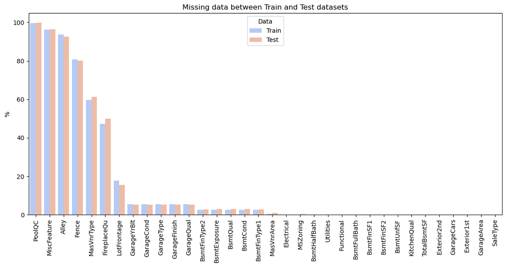

```python
train_missing['Data'] = 'Train'
test_missing['Data'] = 'Test'

missing_total = pd.concat([train_missing[['Percent', 'Data']], test_missing[['Percent', 'Data']]])

plt.figure(figsize=(14,6))
sns.barplot(data=missing_total, x=missing_total.index, y='Percent', hue='Data', palette='coolwarm')
plt.title('Missing data between Train and Test datasets')
plt.ylabel('%')

plt.xticks(rotation=90)
plt.show()
```

# 3. Identification of variable types

#### Numeric

```python
# number columns for train and test datasets
train_data_num_c = train_data.select_dtypes(include=['int64', 'float64'])
test_data_num_c = test_data.select_dtypes(include=['int64', 'float64'])

print(f'Train data number columns:\n{train_data_num_c.columns}\n')
print(f'Test data number columns:\n{test_data_num_c.columns}')
```

```
Train data number columns:
Index(['Id', 'MSSubClass', 'LotFrontage', 'LotArea', 'OverallQual',
       'OverallCond', 'YearBuilt', 'YearRemodAdd', 'MasVnrArea', 'BsmtFinSF1',
       'BsmtFinSF2', 'BsmtUnfSF', 'TotalBsmtSF', '1stFlrSF', '2ndFlrSF',
       'LowQualFinSF', 'GrLivArea', 'BsmtFullBath', 'BsmtHalfBath', 'FullBath',
       'HalfBath', 'BedroomAbvGr', 'KitchenAbvGr', 'TotRmsAbvGrd',
       'Fireplaces', 'GarageYrBlt', 'GarageCars', 'GarageArea', 'WoodDeckSF',
       'OpenPorchSF', 'EnclosedPorch', '3SsnPorch', 'ScreenPorch', 'PoolArea',
       'MiscVal', 'MoSold', 'YrSold', 'SalePrice'],
      dtype='object')

Test data number columns:
Index(['Id', 'MSSubClass', 'LotFrontage', 'LotArea', 'OverallQual',
       'OverallCond', 'YearBuilt', 'YearRemodAdd', 'MasVnrArea', 'BsmtFinSF1',
       'BsmtFinSF2', 'BsmtUnfSF', 'TotalBsmtSF', '1stFlrSF', '2ndFlrSF',
       'LowQualFinSF', 'GrLivArea', 'BsmtFullBath', 'BsmtHalfBath', 'FullBath',
       'HalfBath', 'BedroomAbvGr', 'KitchenAbvGr', 'TotRmsAbvGrd',
       'Fireplaces', 'GarageYrBlt', 'GarageCars', 'GarageArea', 'WoodDeckSF',
       'OpenPorchSF', 'EnclosedPorch', '3SsnPorch', 'ScreenPorch', 'PoolArea',
       'MiscVal', 'MoSold', 'YrSold'],
      dtype='object')
```

```python
train_data_num_c.head()
```

|  | Id | MSSubClass | LotFrontage | LotArea | OverallQual | OverallCond | YearBuilt | YearRemodAdd | MasVnrArea | BsmtFinSF1 | ... | WoodDeckSF | OpenPorchSF | EnclosedPorch | 3SsnPorch | ScreenPorch | PoolArea | MiscVal | MoSold | YrSold | SalePrice |
| --- | --- | --- | --- | --- | --- | --- | --- | --- | --- | --- | --- | --- | --- | --- | --- | --- | --- | --- | --- | --- | --- |
| 0 | 1 | 60 | 65.0 | 8450 | 7 | 5 | 2003 | 2003 | 196.0 | 706 | ... | 0 | 61 | 0 | 0 | 0 | 0 | 0 | 2 | 2008 | 208500 |
| 1 | 2 | 20 | 80.0 | 9600 | 6 | 8 | 1976 | 1976 | 0.0 | 978 | ... | 298 | 0 | 0 | 0 | 0 | 0 | 0 | 5 | 2007 | 181500 |
| 2 | 3 | 60 | 68.0 | 11250 | 7 | 5 | 2001 | 2002 | 162.0 | 486 | ... | 0 | 42 | 0 | 0 | 0 | 0 | 0 | 9 | 2008 | 223500 |
| 3 | 4 | 70 | 60.0 | 9550 | 7 | 5 | 1915 | 1970 | 0.0 | 216 | ... | 0 | 35 | 272 | 0 | 0 | 0 | 0 | 2 | 2006 | 140000 |
| 4 | 5 | 60 | 84.0 | 14260 | 8 | 5 | 2000 | 2000 | 350.0 | 655 | ... | 192 | 84 | 0 | 0 | 0 | 0 | 0 | 12 | 2008 | 250000 |

5 rows × 38 columns

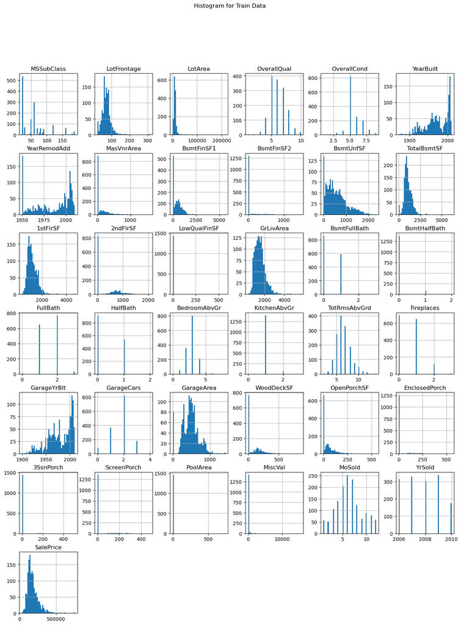

```python
train_data_num_c.drop(columns='Id').hist(figsize=(16, 20), bins=50)
plt.suptitle('Histogram for Train Data')
plt.show()
```

#### Categorical

```python
# categorical columns for train and test datasets
train_data_cat_c = train_data.select_dtypes(include=['object'])
test_data_cat_c = test_data.select_dtypes(include=['object'])

print(f'Train data categorical columns:\n{test_data_cat_c.columns}\n')
print(f'Test data categorical columns:\n{test_data_cat_c.columns}')
```

```
Train data categorical columns:
Index(['MSZoning', 'Street', 'Alley', 'LotShape', 'LandContour', 'Utilities',
       'LotConfig', 'LandSlope', 'Neighborhood', 'Condition1', 'Condition2',
       'BldgType', 'HouseStyle', 'RoofStyle', 'RoofMatl', 'Exterior1st',
       'Exterior2nd', 'MasVnrType', 'ExterQual', 'ExterCond', 'Foundation',
       'BsmtQual', 'BsmtCond', 'BsmtExposure', 'BsmtFinType1', 'BsmtFinType2',
       'Heating', 'HeatingQC', 'CentralAir', 'Electrical', 'KitchenQual',
       'Functional', 'FireplaceQu', 'GarageType', 'GarageFinish', 'GarageQual',
       'GarageCond', 'PavedDrive', 'PoolQC', 'Fence', 'MiscFeature',
       'SaleType', 'SaleCondition'],
      dtype='object')

Test data categorical columns:
Index(['MSZoning', 'Street', 'Alley', 'LotShape', 'LandContour', 'Utilities',
       'LotConfig', 'LandSlope', 'Neighborhood', 'Condition1', 'Condition2',
       'BldgType', 'HouseStyle', 'RoofStyle', 'RoofMatl', 'Exterior1st',
       'Exterior2nd', 'MasVnrType', 'ExterQual', 'ExterCond', 'Foundation',
       'BsmtQual', 'BsmtCond', 'BsmtExposure', 'BsmtFinType1', 'BsmtFinType2',
       'Heating', 'HeatingQC', 'CentralAir', 'Electrical', 'KitchenQual',
       'Functional', 'FireplaceQu', 'GarageType', 'GarageFinish', 'GarageQual',
       'GarageCond', 'PavedDrive', 'PoolQC', 'Fence', 'MiscFeature',
       'SaleType', 'SaleCondition'],
      dtype='object')
```

```python
# unique categorical values

def unique_categorical(cat_dataset, dataset):
    for col in cat_dataset:
        print(f'{col}: {dataset[col].nunique()}')


print(f'Train data unique values:{unique_categorical(train_data_cat_c, train_data)}\n')
print(f'Test data unique values:{unique_categorical(test_data_cat_c, test_data)}\n')
```

```
MSZoning: 5
Street: 2
Alley: 2
LotShape: 4
LandContour: 4
Utilities: 2
LotConfig: 5
LandSlope: 3
Neighborhood: 25
Condition1: 9
Condition2: 8
BldgType: 5
HouseStyle: 8
RoofStyle: 6
RoofMatl: 8
Exterior1st: 15
Exterior2nd: 16
MasVnrType: 3
ExterQual: 4
ExterCond: 5
Foundation: 6
BsmtQual: 4
BsmtCond: 4
BsmtExposure: 4
BsmtFinType1: 6
BsmtFinType2: 6
Heating: 6
HeatingQC: 5
CentralAir: 2
Electrical: 5
KitchenQual: 4
Functional: 7
FireplaceQu: 5
GarageType: 6
GarageFinish: 3
GarageQual: 5
GarageCond: 5
PavedDrive: 3
PoolQC: 3
Fence: 4
```

[output cut: 34 more lines]

```
Electrical: 4
KitchenQual: 4
Functional: 7
FireplaceQu: 5
GarageType: 6
GarageFinish: 3
GarageQual: 4
GarageCond: 5
PavedDrive: 3
PoolQC: 2
Fence: 4
MiscFeature: 3
SaleType: 9
SaleCondition: 6
Test data unique values:None
```

# 3. Identifying potential issues in your data

check numeric variables for anomalies (e.g. outliers)

```python
# train_data_num_c
train_data_num_c.describe().round(3)
```

|  | Id | MSSubClass | LotFrontage | LotArea | OverallQual | OverallCond | YearBuilt | YearRemodAdd | MasVnrArea | BsmtFinSF1 | ... | WoodDeckSF | OpenPorchSF | EnclosedPorch | 3SsnPorch | ScreenPorch | PoolArea | MiscVal | MoSold | YrSold | SalePrice |
| --- | --- | --- | --- | --- | --- | --- | --- | --- | --- | --- | --- | --- | --- | --- | --- | --- | --- | --- | --- | --- | --- |
| count | 1460.00 | 1460.000 | 1201.000 | 1460.000 | 1460.000 | 1460.000 | 1460.000 | 1460.000 | 1452.000 | 1460.000 | ... | 1460.000 | 1460.000 | 1460.000 | 1460.000 | 1460.000 | 1460.000 | 1460.000 | 1460.000 | 1460.000 | 1460.000 |
| mean | 730.50 | 56.897 | 70.050 | 10516.828 | 6.099 | 5.575 | 1971.268 | 1984.866 | 103.685 | 443.640 | ... | 94.245 | 46.660 | 21.954 | 3.410 | 15.061 | 2.759 | 43.489 | 6.322 | 2007.816 | 180921.196 |
| std | 421.61 | 42.301 | 24.285 | 9981.265 | 1.383 | 1.113 | 30.203 | 20.645 | 181.066 | 456.098 | ... | 125.339 | 66.256 | 61.119 | 29.317 | 55.757 | 40.177 | 496.123 | 2.704 | 1.328 | 79442.503 |
| min | 1.00 | 20.000 | 21.000 | 1300.000 | 1.000 | 1.000 | 1872.000 | 1950.000 | 0.000 | 0.000 | ... | 0.000 | 0.000 | 0.000 | 0.000 | 0.000 | 0.000 | 0.000 | 1.000 | 2006.000 | 34900.000 |
| 25% | 365.75 | 20.000 | 59.000 | 7553.500 | 5.000 | 5.000 | 1954.000 | 1967.000 | 0.000 | 0.000 | ... | 0.000 | 0.000 | 0.000 | 0.000 | 0.000 | 0.000 | 0.000 | 5.000 | 2007.000 | 129975.000 |
| 50% | 730.50 | 50.000 | 69.000 | 9478.500 | 6.000 | 5.000 | 1973.000 | 1994.000 | 0.000 | 383.500 | ... | 0.000 | 25.000 | 0.000 | 0.000 | 0.000 | 0.000 | 0.000 | 6.000 | 2008.000 | 163000.000 |
| 75% | 1095.25 | 70.000 | 80.000 | 11601.500 | 7.000 | 6.000 | 2000.000 | 2004.000 | 166.000 | 712.250 | ... | 168.000 | 68.000 | 0.000 | 0.000 | 0.000 | 0.000 | 0.000 | 8.000 | 2009.000 | 214000.000 |
| max | 1460.00 | 190.000 | 313.000 | 215245.000 | 10.000 | 9.000 | 2010.000 | 2010.000 | 1600.000 | 5644.000 | ... | 857.000 | 547.000 | 552.000 | 508.000 | 480.000 | 738.000 | 15500.000 | 12.000 | 2010.000 | 755000.000 |

8 rows × 38 columns

```python
# test_data_num_c
test_data_num_c.describe().round(3)
```

|  | Id | MSSubClass | LotFrontage | LotArea | OverallQual | OverallCond | YearBuilt | YearRemodAdd | MasVnrArea | BsmtFinSF1 | ... | GarageArea | WoodDeckSF | OpenPorchSF | EnclosedPorch | 3SsnPorch | ScreenPorch | PoolArea | MiscVal | MoSold | YrSold |
| --- | --- | --- | --- | --- | --- | --- | --- | --- | --- | --- | --- | --- | --- | --- | --- | --- | --- | --- | --- | --- | --- |
| count | 1459.000 | 1459.000 | 1232.000 | 1459.000 | 1459.000 | 1459.000 | 1459.000 | 1459.000 | 1444.000 | 1458.000 | ... | 1458.000 | 1459.000 | 1459.000 | 1459.000 | 1459.000 | 1459.000 | 1459.000 | 1459.000 | 1459.000 | 1459.000 |
| mean | 2190.000 | 57.378 | 68.580 | 9819.161 | 6.079 | 5.554 | 1971.358 | 1983.663 | 100.709 | 439.204 | ... | 472.769 | 93.175 | 48.314 | 24.243 | 1.794 | 17.064 | 1.744 | 58.168 | 6.104 | 2007.770 |
| std | 421.321 | 42.747 | 22.377 | 4955.517 | 1.437 | 1.114 | 30.390 | 21.130 | 177.626 | 455.268 | ... | 217.049 | 127.745 | 68.883 | 67.228 | 20.208 | 56.610 | 30.492 | 630.807 | 2.722 | 1.302 |
| min | 1461.000 | 20.000 | 21.000 | 1470.000 | 1.000 | 1.000 | 1879.000 | 1950.000 | 0.000 | 0.000 | ... | 0.000 | 0.000 | 0.000 | 0.000 | 0.000 | 0.000 | 0.000 | 0.000 | 1.000 | 2006.000 |
| 25% | 1825.500 | 20.000 | 58.000 | 7391.000 | 5.000 | 5.000 | 1953.000 | 1963.000 | 0.000 | 0.000 | ... | 318.000 | 0.000 | 0.000 | 0.000 | 0.000 | 0.000 | 0.000 | 0.000 | 4.000 | 2007.000 |
| 50% | 2190.000 | 50.000 | 67.000 | 9399.000 | 6.000 | 5.000 | 1973.000 | 1992.000 | 0.000 | 350.500 | ... | 480.000 | 0.000 | 28.000 | 0.000 | 0.000 | 0.000 | 0.000 | 0.000 | 6.000 | 2008.000 |
| 75% | 2554.500 | 70.000 | 80.000 | 11517.500 | 7.000 | 6.000 | 2001.000 | 2004.000 | 164.000 | 753.500 | ... | 576.000 | 168.000 | 72.000 | 0.000 | 0.000 | 0.000 | 0.000 | 0.000 | 8.000 | 2009.000 |
| max | 2919.000 | 190.000 | 200.000 | 56600.000 | 10.000 | 9.000 | 2010.000 | 2010.000 | 1290.000 | 4010.000 | ... | 1488.000 | 1424.000 | 742.000 | 1012.000 | 360.000 | 576.000 | 800.000 | 17000.000 | 12.000 | 2010.000 |

8 rows × 37 columns

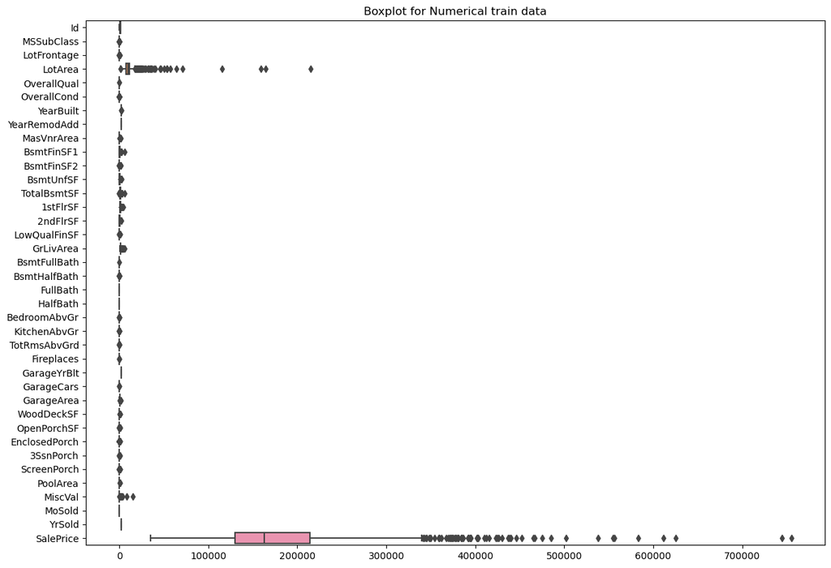

```python
plt.figure(figsize=(14,10))

sns.boxplot(data=train_data_num_c, orient='h')
plt.title('Boxplot for Numerical train data')
plt.show()
```

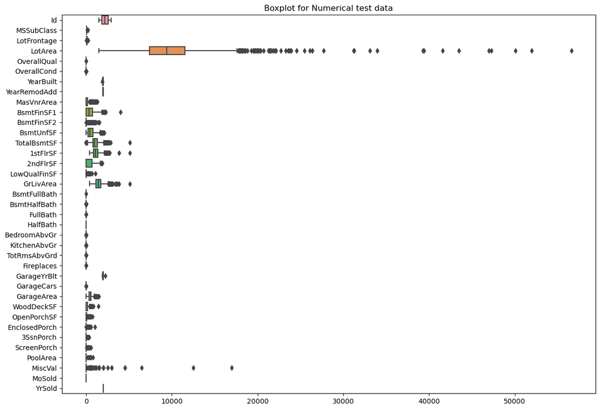

```python
plt.figure(figsize=(14,10))

sns.boxplot(data=test_data_num_c, orient='h')
plt.title('Boxplot for Numerical test data')
plt.show()
```

# 4. Exploratory Data Analysis based on SalePrice

```python
train_data[['SalePrice']].describe().round(3)
```

|  | SalePrice |
| --- | --- |
| count | 1460.000 |
| mean | 180921.196 |
| std | 79442.503 |
| min | 34900.000 |
| 25% | 129975.000 |
| 50% | 163000.000 |
| 75% | 214000.000 |
| max | 755000.000 |

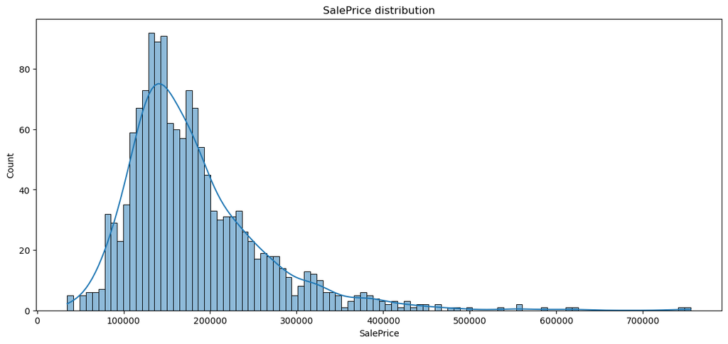

```python
plt.figure(figsize=(14,6))

sns.histplot(train_data['SalePrice'], bins=100, kde=True)
plt.title('SalePrice distribution')
plt.show()
```

The highest number of house offers are between over 100.000,00 and up to 250.000,00

## 4.1 Checking outliers for SalePrice

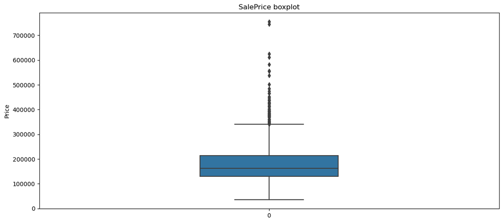

```python
plt.figure(figsize=(14,6))
sns.boxplot(train_data['SalePrice'], width=0.3)
plt.title('SalePrice boxplot')
plt.ylabel('Price')

plt.show()
```

We see a lot of outliers over the approx. 350.000,00$. That's why we can thinking that over that price train data includes single offers of houses.

## 4.2 SalePrice Numerical Correlation

For checking correlation we need to choose just the numeric values of columns

```python
train_corr = train_data_num_c.drop(columns='Id').corr()

train_corr.round(3)
```

|  | MSSubClass | LotFrontage | LotArea | OverallQual | OverallCond | YearBuilt | YearRemodAdd | MasVnrArea | BsmtFinSF1 | BsmtFinSF2 | ... | WoodDeckSF | OpenPorchSF | EnclosedPorch | 3SsnPorch | ScreenPorch | PoolArea | MiscVal | MoSold | YrSold | SalePrice |
| --- | --- | --- | --- | --- | --- | --- | --- | --- | --- | --- | --- | --- | --- | --- | --- | --- | --- | --- | --- | --- | --- |
| MSSubClass | 1.000 | -0.386 | -0.140 | 0.033 | -0.059 | 0.028 | 0.041 | 0.023 | -0.070 | -0.066 | ... | -0.013 | -0.006 | -0.012 | -0.044 | -0.026 | 0.008 | -0.008 | -0.014 | -0.021 | -0.084 |
| LotFrontage | -0.386 | 1.000 | 0.426 | 0.252 | -0.059 | 0.123 | 0.089 | 0.193 | 0.234 | 0.050 | ... | 0.089 | 0.152 | 0.011 | 0.070 | 0.041 | 0.206 | 0.003 | 0.011 | 0.007 | 0.352 |
| LotArea | -0.140 | 0.426 | 1.000 | 0.106 | -0.006 | 0.014 | 0.014 | 0.104 | 0.214 | 0.111 | ... | 0.172 | 0.085 | -0.018 | 0.020 | 0.043 | 0.078 | 0.038 | 0.001 | -0.014 | 0.264 |
| OverallQual | 0.033 | 0.252 | 0.106 | 1.000 | -0.092 | 0.572 | 0.551 | 0.412 | 0.240 | -0.059 | ... | 0.239 | 0.309 | -0.114 | 0.030 | 0.065 | 0.065 | -0.031 | 0.071 | -0.027 | 0.791 |
| OverallCond | -0.059 | -0.059 | -0.006 | -0.092 | 1.000 | -0.376 | 0.074 | -0.128 | -0.046 | 0.040 | ... | -0.003 | -0.033 | 0.070 | 0.026 | 0.055 | -0.002 | 0.069 | -0.004 | 0.044 | -0.078 |
| YearBuilt | 0.028 | 0.123 | 0.014 | 0.572 | -0.376 | 1.000 | 0.593 | 0.316 | 0.250 | -0.049 | ... | 0.225 | 0.189 | -0.387 | 0.031 | -0.050 | 0.005 | -0.034 | 0.012 | -0.014 | 0.523 |
| YearRemodAdd | 0.041 | 0.089 | 0.014 | 0.551 | 0.074 | 0.593 | 1.000 | 0.180 | 0.128 | -0.068 | ... | 0.206 | 0.226 | -0.194 | 0.045 | -0.039 | 0.006 | -0.010 | 0.021 | 0.036 | 0.507 |
| MasVnrArea | 0.023 | 0.193 | 0.104 | 0.412 | -0.128 | 0.316 | 0.180 | 1.000 | 0.265 | -0.072 | ... | 0.160 | 0.126 | -0.110 | 0.019 | 0.061 | 0.012 | -0.030 | -0.006 | -0.008 | 0.477 |
| BsmtFinSF1 | -0.070 | 0.234 | 0.214 | 0.240 | -0.046 | 0.250 | 0.128 | 0.265 | 1.000 | -0.050 | ... | 0.204 | 0.112 | -0.102 | 0.026 | 0.062 | 0.140 | 0.004 | -0.016 | 0.014 | 0.386 |
| BsmtFinSF2 | -0.066 | 0.050 | 0.111 | -0.059 | 0.040 | -0.049 | -0.068 | -0.072 | -0.050 | 1.000 | ... | 0.068 | 0.003 | 0.037 | -0.030 | 0.089 | 0.042 | 0.005 | -0.015 | 0.032 | -0.011 |
| BsmtUnfSF | -0.141 | 0.133 | -0.003 | 0.308 | -0.137 | 0.149 | 0.181 | 0.114 | -0.495 | -0.209 | ... | -0.005 | 0.129 | -0.003 | 0.021 | -0.013 | -0.035 | -0.024 | 0.035 | -0.041 | 0.214 |
| TotalBsmtSF | -0.239 | 0.392 | 0.261 | 0.538 | -0.171 | 0.391 | 0.291 | 0.364 | 0.522 | 0.105 | ... | 0.232 | 0.247 | -0.095 | 0.037 | 0.084 | 0.126 | -0.018 | 0.013 | -0.015 | 0.614 |
| 1stFlrSF | -0.252 | 0.457 | 0.299 | 0.476 | -0.144 | 0.282 | 0.240 | 0.345 | 0.446 | 0.097 | ... | 0.235 | 0.212 | -0.065 | 0.056 | 0.089 | 0.132 | -0.021 | 0.031 | -0.014 | 0.606 |
| 2ndFlrSF | 0.308 | 0.080 | 0.051 | 0.295 | 0.029 | 0.010 | 0.140 | 0.175 | -0.137 | -0.099 | ... | 0.092 | 0.208 | 0.062 | -0.024 | 0.041 | 0.081 | 0.016 | 0.035 | -0.029 | 0.319 |
| LowQualFinSF | 0.046 | 0.038 | 0.005 | -0.030 | 0.025 | -0.184 | -0.062 | -0.069 | -0.065 | 0.015 | ... | -0.025 | 0.018 | 0.061 | -0.004 | 0.027 | 0.062 | -0.004 | -0.022 | -0.029 | -0.026 |
| GrLivArea | 0.075 | 0.403 | 0.263 | 0.593 | -0.080 | 0.199 | 0.287 | 0.391 | 0.208 | -0.010 | ... | 0.247 | 0.330 | 0.009 | 0.021 | 0.102 | 0.170 | -0.002 | 0.050 | -0.037 | 0.709 |
| BsmtFullBath | 0.003 | 0.101 | 0.158 | 0.111 | -0.055 | 0.188 | 0.119 | 0.085 | 0.649 | 0.159 | ... | 0.175 | 0.067 | -0.050 | -0.000 | 0.023 | 0.068 | -0.023 | -0.025 | 0.067 | 0.227 |
| BsmtHalfBath | -0.002 | -0.007 | 0.048 | -0.040 | 0.118 | -0.038 | -0.012 | 0.027 | 0.067 | 0.071 | ... | 0.040 | -0.025 | -0.009 | 0.035 | 0.032 | 0.020 | -0.007 | 0.033 | -0.047 | -0.017 |
| FullBath | 0.132 | 0.199 | 0.126 | 0.551 | -0.194 | 0.468 | 0.439 | 0.277 | 0.059 | -0.076 | ... | 0.188 | 0.260 | -0.115 | 0.035 | -0.008 | 0.050 | -0.014 | 0.056 | -0.020 | 0.561 |
| HalfBath | 0.177 | 0.054 | 0.014 | 0.273 | -0.061 | 0.243 | 0.183 | 0.201 | 0.004 | -0.032 | ... | 0.108 | 0.200 | -0.095 | -0.005 | 0.072 | 0.022 | 0.001 | -0.009 | -0.010 | 0.284 |
| BedroomAbvGr | -0.023 | 0.263 | 0.120 | 0.102 | 0.013 | -0.071 | -0.041 | 0.103 | -0.107 | -0.016 | ... | 0.047 | 0.094 | 0.042 | -0.024 | 0.044 | 0.071 | 0.008 | 0.047 | -0.036 | 0.168 |
| KitchenAbvGr | 0.282 | -0.006 | -0.018 | -0.184 | -0.087 | -0.175 | -0.150 | -0.038 | -0.081 | -0.041 | ... | -0.090 | -0.070 | 0.037 | -0.025 | -0.052 | -0.015 | 0.062 | 0.027 | 0.032 | -0.136 |
| TotRmsAbvGrd | 0.040 | 0.352 | 0.190 | 0.427 | -0.058 | 0.096 | 0.192 | 0.281 | 0.044 | -0.035 | ... | 0.166 | 0.234 | 0.004 | -0.007 | 0.059 | 0.084 | 0.025 | 0.037 | -0.035 | 0.534 |
| Fireplaces | -0.046 | 0.267 | 0.271 | 0.397 | -0.024 | 0.148 | 0.113 | 0.249 | 0.260 | 0.047 | ... | 0.200 | 0.169 | -0.025 | 0.011 | 0.185 | 0.095 | 0.001 | 0.046 | -0.024 | 0.467 |
| GarageYrBlt | 0.085 | 0.070 | -0.025 | 0.548 | -0.324 | 0.826 | 0.642 | 0.253 | 0.153 | -0.088 | ... | 0.225 | 0.228 | -0.297 | 0.024 | -0.075 | -0.015 | -0.032 | 0.005 | -0.001 | 0.486 |
| GarageCars | -0.040 | 0.286 | 0.155 | 0.601 | -0.186 | 0.538 | 0.421 | 0.364 | 0.224 | -0.038 | ... | 0.226 | 0.214 | -0.151 | 0.036 | 0.050 | 0.021 | -0.043 | 0.041 | -0.039 | 0.640 |
| GarageArea | -0.099 | 0.345 | 0.180 | 0.562 | -0.152 | 0.479 | 0.372 | 0.373 | 0.297 | -0.018 | ... | 0.225 | 0.241 | -0.122 | 0.035 | 0.051 | 0.061 | -0.027 | 0.028 | -0.027 | 0.623 |
| WoodDeckSF | -0.013 | 0.089 | 0.172 | 0.239 | -0.003 | 0.225 | 0.206 | 0.160 | 0.204 | 0.068 | ... | 1.000 | 0.059 | -0.126 | -0.033 | -0.074 | 0.073 | -0.010 | 0.021 | 0.022 | 0.324 |
| OpenPorchSF | -0.006 | 0.152 | 0.085 | 0.309 | -0.033 | 0.189 | 0.226 | 0.126 | 0.112 | 0.003 | ... | 0.059 | 1.000 | -0.093 | -0.006 | 0.074 | 0.061 | -0.019 | 0.071 | -0.058 | 0.316 |
| EnclosedPorch | -0.012 | 0.011 | -0.018 | -0.114 | 0.070 | -0.387 | -0.194 | -0.110 | -0.102 | 0.037 | ... | -0.126 | -0.093 | 1.000 | -0.037 | -0.083 | 0.054 | 0.018 | -0.029 | -0.010 | -0.129 |
| 3SsnPorch | -0.044 | 0.070 | 0.020 | 0.030 | 0.026 | 0.031 | 0.045 | 0.019 | 0.026 | -0.030 | ... | -0.033 | -0.006 | -0.037 | 1.000 | -0.031 | -0.008 | 0.000 | 0.029 | 0.019 | 0.045 |
| ScreenPorch | -0.026 | 0.041 | 0.043 | 0.065 | 0.055 | -0.050 | -0.039 | 0.061 | 0.062 | 0.089 | ... | -0.074 | 0.074 | -0.083 | -0.031 | 1.000 | 0.051 | 0.032 | 0.023 | 0.011 | 0.111 |
| PoolArea | 0.008 | 0.206 | 0.078 | 0.065 | -0.002 | 0.005 | 0.006 | 0.012 | 0.140 | 0.042 | ... | 0.073 | 0.061 | 0.054 | -0.008 | 0.051 | 1.000 | 0.030 | -0.034 | -0.060 | 0.092 |
| MiscVal | -0.008 | 0.003 | 0.038 | -0.031 | 0.069 | -0.034 | -0.010 | -0.030 | 0.004 | 0.005 | ... | -0.010 | -0.019 | 0.018 | 0.000 | 0.032 | 0.030 | 1.000 | -0.006 | 0.005 | -0.021 |
| MoSold | -0.014 | 0.011 | 0.001 | 0.071 | -0.004 | 0.012 | 0.021 | -0.006 | -0.016 | -0.015 | ... | 0.021 | 0.071 | -0.029 | 0.029 | 0.023 | -0.034 | -0.006 | 1.000 | -0.146 | 0.046 |
| YrSold | -0.021 | 0.007 | -0.014 | -0.027 | 0.044 | -0.014 | 0.036 | -0.008 | 0.014 | 0.032 | ... | 0.022 | -0.058 | -0.010 | 0.019 | 0.011 | -0.060 | 0.005 | -0.146 | 1.000 | -0.029 |
| SalePrice | -0.084 | 0.352 | 0.264 | 0.791 | -0.078 | 0.523 | 0.507 | 0.477 | 0.386 | -0.011 | ... | 0.324 | 0.316 | -0.129 | 0.045 | 0.111 | 0.092 | -0.021 | 0.046 | -0.029 | 1.000 |

37 rows × 37 columns

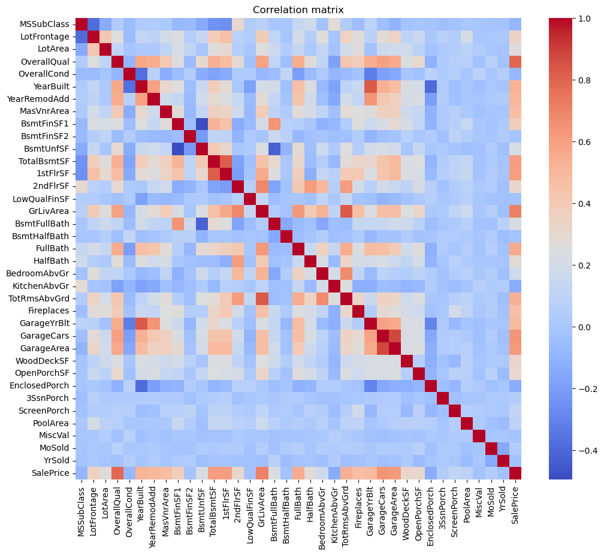

```python
plt.figure(figsize=(12, 10))
sns.heatmap(train_corr, cmap='coolwarm')
plt.title('Correlation matrix')
plt.show()
```

```python
train_corr['SalePrice'].sort_values(ascending=False)
```

```
SalePrice        1.000000
OverallQual      0.790982
GrLivArea        0.708624
GarageCars       0.640409
GarageArea       0.623431
TotalBsmtSF      0.613581
1stFlrSF         0.605852
FullBath         0.560664
TotRmsAbvGrd     0.533723
YearBuilt        0.522897
YearRemodAdd     0.507101
GarageYrBlt      0.486362
MasVnrArea       0.477493
Fireplaces       0.466929
BsmtFinSF1       0.386420
LotFrontage      0.351799
WoodDeckSF       0.324413
2ndFlrSF         0.319334
OpenPorchSF      0.315856
HalfBath         0.284108
LotArea          0.263843
BsmtFullBath     0.227122
BsmtUnfSF        0.214479
BedroomAbvGr     0.168213
ScreenPorch      0.111447
PoolArea         0.092404
MoSold           0.046432
3SsnPorch        0.044584
BsmtFinSF2      -0.011378
BsmtHalfBath    -0.016844
MiscVal         -0.021190
LowQualFinSF    -0.025606
YrSold          -0.028923
OverallCond     -0.077856
MSSubClass      -0.084284
EnclosedPorch   -0.128578
KitchenAbvGr    -0.135907
Name: SalePrice, dtype: float64
```

Correlation data with the highest score with SalePrice have:

- OverallQual
- GrLivArea
- GarageCars
- GarageArea
- TotalBsmtSF
- 1stFlrSF
- FullBath
- TotRmsAbvGrd
- YearBuilt

Based on values with highest correlation, now we will use a raw data from train_data to visualize it

Let's check relations between them and SalePrice on plots

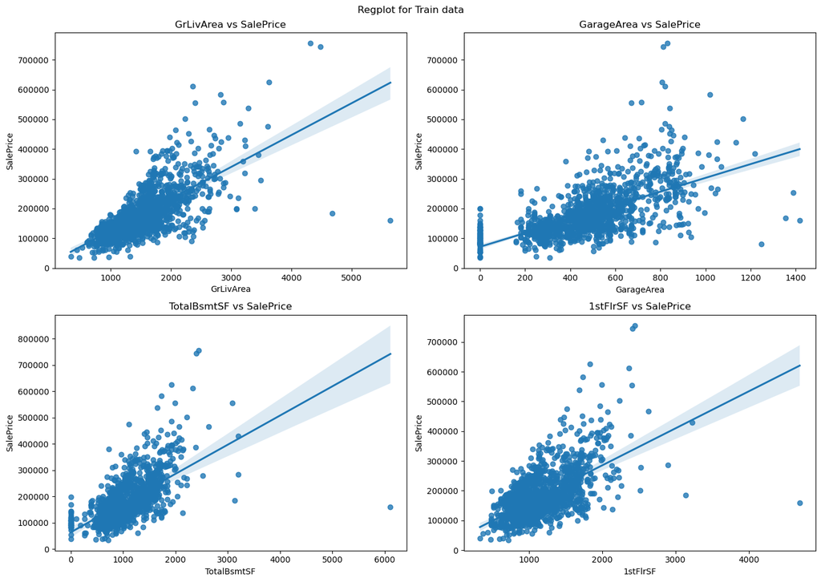

```python
# scatterplot with regplot
features_scatter = train_data[['GrLivArea', 'GarageArea', 'TotalBsmtSF', '1stFlrSF']]

fig, axes = plt.subplots(2, 2, figsize=(14,10))

for (column, ax) in zip(features_scatter.columns, axes.ravel()):
    # ax.scatter(train_data[column], train_data['SalePrice'], alpha=0.5)
    sns.regplot(x=train_data[column], y=train_data['SalePrice'], ax=ax)
    ax.set_title(f'{column} vs SalePrice')
    ax.set_xlabel(column)
    ax.set_ylabel('SalePrice')


plt.suptitle('Regplot for Train data')
plt.tight_layout()
plt.show()
```

As we can see on regplots above the best fit are shown on GrLivArea and GarageArea compare to Sale Price, but the result isn't perfect.

#### The sets do not represent a linear system, which may suggest the use of the Random Forest Regression model

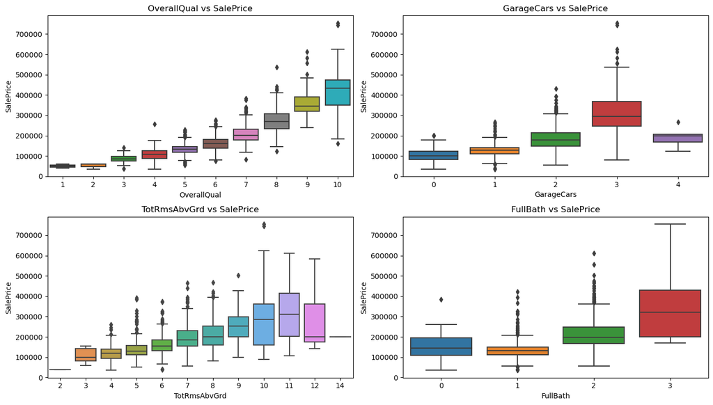

```python
# boxplot
features_box = train_data[['OverallQual', 'GarageCars', 'TotRmsAbvGrd', 'FullBath']]

fig, axes = plt.subplots(2,2, figsize=(14,8))

for (column, ax) in zip(features_box.columns, axes.ravel()):
    sns.boxplot(x=train_data[column], y=train_data['SalePrice'], ax=ax)
    ax.set_title(f'{column} vs SalePrice')

plt.tight_layout()
plt.show()
```

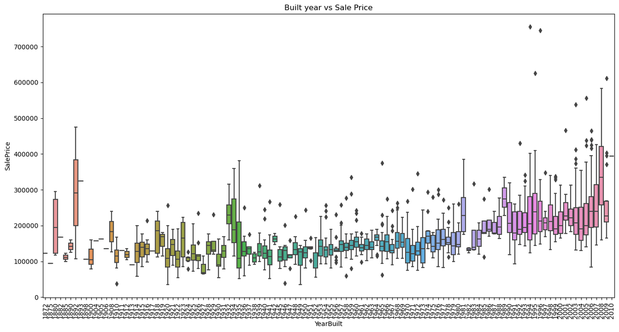

```python
plt.figure(figsize=(16,8))
sns.boxplot(x=train_data['YearBuilt'], y=train_data['SalePrice'])
plt.title('Built year vs Sale Price')
plt.xticks(rotation=90)

plt.show()
```

Scatter plots and box plots between most correlated values compare with Sale Price

Overall lookig for data

```python
import warnings
warnings.filterwarnings("ignore", category=FutureWarning)
```

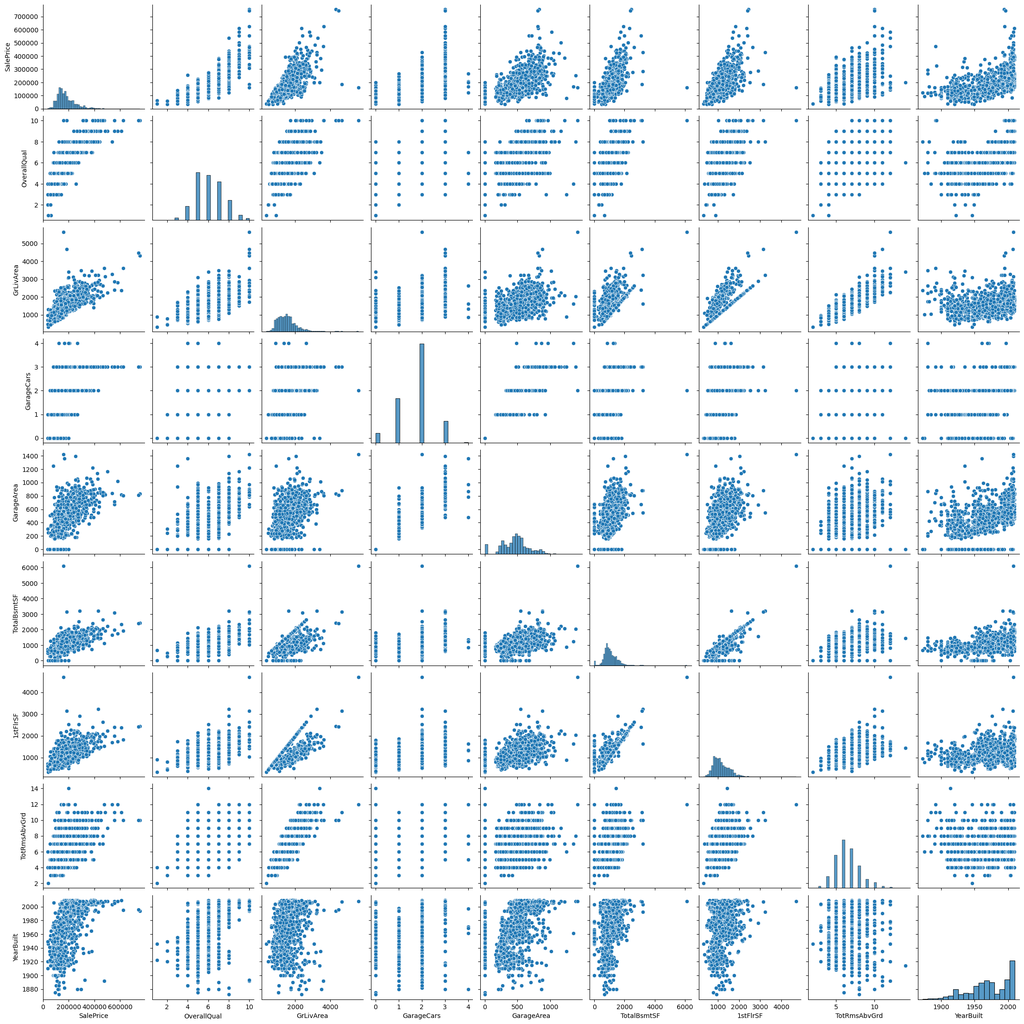

```python
features_pair = ['SalePrice', 'OverallQual', 'GrLivArea', 'GarageCars', 'GarageArea', 'TotalBsmtSF', '1stFlrSF', 'TotRmsAbvGrd', 'YearBuilt']

sns.pairplot(train_data[features_pair])
plt.show()
```

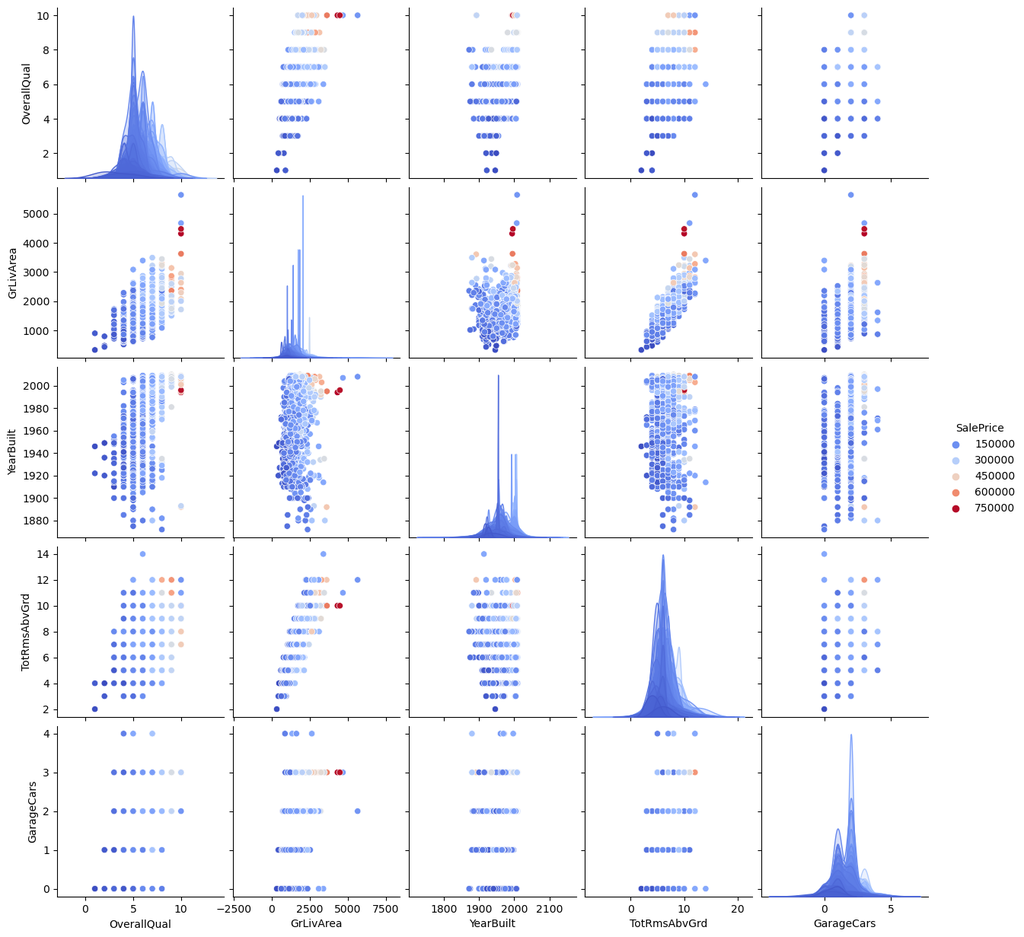

```python
# pairplot with hue='SalePrice' for less columns
features_pair_small = ['SalePrice', 'OverallQual', 'GrLivArea', 'YearBuilt', 'TotRmsAbvGrd', 'GarageCars']

plt.figure(figsize=(14,6))
sns.pairplot(train_data[features_pair_small], hue='SalePrice', palette='coolwarm')
plt.show()
```

Pairplot Analysis:

- Each pairplot shows high correlation between values and Sale Price (we choose the data with highest correlation)

## 4.3 SalePrice categorical values

Now we will focus on categorical data compare to SalePrice

```python
train_data_cat_c.columns.difference(train_corr['SalePrice'].index)
```

```
Index(['Alley', 'BldgType', 'BsmtCond', 'BsmtExposure', 'BsmtFinType1',
       'BsmtFinType2', 'BsmtQual', 'CentralAir', 'Condition1', 'Condition2',
       'Electrical', 'ExterCond', 'ExterQual', 'Exterior1st', 'Exterior2nd',
       'Fence', 'FireplaceQu', 'Foundation', 'Functional', 'GarageCond',
       'GarageFinish', 'GarageQual', 'GarageType', 'Heating', 'HeatingQC',
       'HouseStyle', 'KitchenQual', 'LandContour', 'LandSlope', 'LotConfig',
       'LotShape', 'MSZoning', 'MasVnrType', 'MiscFeature', 'Neighborhood',
       'PavedDrive', 'PoolQC', 'RoofMatl', 'RoofStyle', 'SaleCondition',
       'SaleType', 'Street', 'Utilities'],
      dtype='object')
```

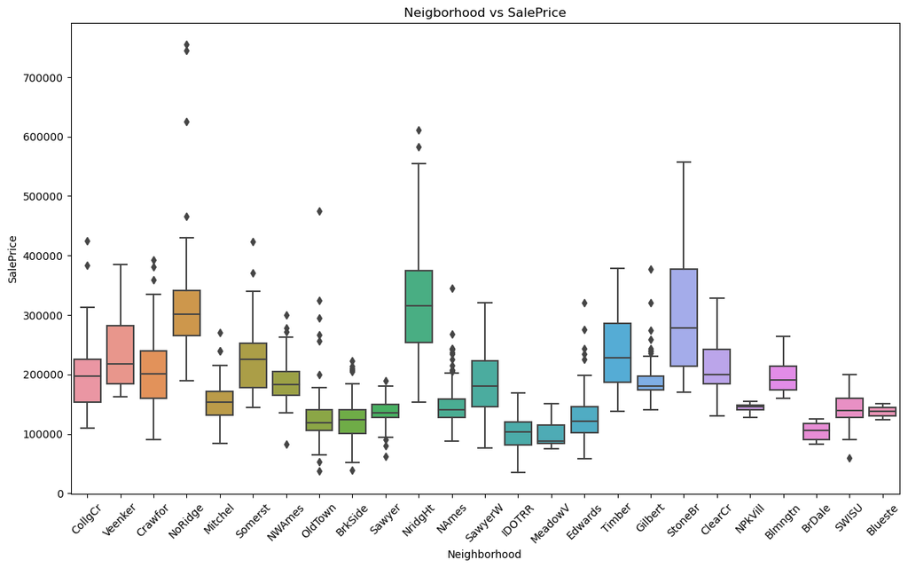

```python
plt.figure(figsize=(14,8))
sns.boxplot(x=train_data['Neighborhood'], y=train_data['SalePrice'])
plt.title('Neigborhood vs SalePrice')
plt.xticks(rotation=45)

plt.show()
```

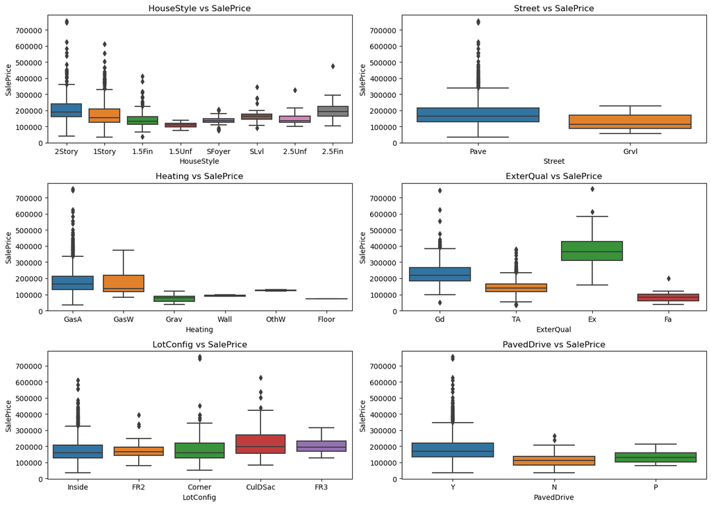

```python
train_categorical = train_data_cat_c[['HouseStyle', 'Street', 'Heating', 'ExterQual', 'LotConfig', 'PavedDrive']]

fig, axes = plt.subplots(3,2, figsize=(14,10))

for (column, ax) in zip(train_categorical.columns, axes.ravel()):
    sns.boxplot(x=train_data[column], y=train_data['SalePrice'], ax=ax)
    ax.set_title(f'{column} vs SalePrice')


plt.tight_layout()
plt.show()
```

## 4.4 Standarization for numeric data

Variables will be on the same scale, so the model will not favor those with baseline values (e.g. GrLivArea).

We need to fill or delete missing data. In our solution we fill missing data by median

```python
train_stand = train_data[['OverallQual', 'GrLivArea', 'GarageCars', 'GarageArea',
                             'TotalBsmtSF', '1stFlrSF', 'FullBath', 'TotRmsAbvGrd', 'YearBuilt']]

train_stand = train_stand.fillna(train_stand.median())
```

```python
scaler = StandardScaler()

train_scaled = scaler.fit_transform(train_stand)
train_scaled
```

```
array([[ 0.65147924,  0.37033344,  0.31172464, ...,  0.78974052,
         0.91220977,  1.05099379],
       [-0.07183611, -0.48251191,  0.31172464, ...,  0.78974052,
        -0.31868327,  0.15673371],
       [ 0.65147924,  0.51501256,  0.31172464, ...,  0.78974052,
        -0.31868327,  0.9847523 ],
       ...,
       [ 0.65147924,  1.56964722, -1.02685765, ...,  0.78974052,
         1.52765629, -1.00249232],
       [-0.79515147, -0.83278768, -1.02685765, ..., -1.02604084,
        -0.93412978, -0.70440562],
       [-0.79515147, -0.49393395, -1.02685765, ..., -1.02604084,
        -0.31868327, -0.20759447]])
```

```python
train_scaled_mean = np.mean(train_scaled, axis=0)
train_scaled_std = np.std(train_scaled, axis=0)

df_results = pd.DataFrame({
    'Category': train_stand.columns,
    'Avg': train_scaled_mean,
    'Std': train_scaled_std
})

df_results
```

|  | Category | Avg | Std |
| --- | --- | --- | --- |
| 0 | OverallQual | 1.387018e-16 | 1.0 |
| 1 | GrLivArea | -1.277517e-16 | 1.0 |
| 2 | GarageCars | 1.216683e-16 | 1.0 |
| 3 | GarageArea | -1.216683e-17 | 1.0 |
| 4 | TotalBsmtSF | 2.457699e-16 | 1.0 |
| 5 | 1stFlrSF | 6.509253e-17 | 1.0 |
| 6 | FullBath | 1.180182e-16 | 1.0 |
| 7 | TotRmsAbvGrd | -1.022014e-16 | 1.0 |
| 8 | YearBuilt | 1.046347e-15 | 1.0 |

Result analysis:

- Avg is very close to the 0 in each category. That inform us about good standarization.
- Std is 1.0 for each category. All features have the same variance distribution.

# 5. ML models

Now we will keep focus on most popular ML models based on standarization data:

- Linear regression
- kNN (K-Nearest Neighbors)

For analysis we use a 9 of categries with best correlation with SalePrice

## 5.1 Linear Regression vs kNN models (9 values)

Based on 9 values with highest correlation

#### Linear Regression model

```python
# preparing data
X = train_stand
y = train_data['SalePrice']

# train data
X_train, X_test, y_train, y_test = train_test_split(X, y, test_size=0.2, random_state=42)


scaler = StandardScaler()
# standarization training data
X_train_scaled = scaler.fit_transform(X_train)
# standarization test data
X_test_scaled = scaler.transform(X_test)

# LinearRegression
model = LinearRegression()
model.fit(X_train_scaled, y_train)

# predict model
y_pred = model.predict(X_test_scaled)

# RMSE
rmse = np.sqrt(mean_squared_error(y_test, y_pred))
rmse_percent = (rmse / y_train.mean()) * 100
print(f'RMSE for Linear Regression: {rmse:.2f} / Percentage: {rmse_percent.round(3)}%')
```

```
RMSE for Linear Regression: 39568.64 / Percentage: 21.808%
```

Root Mean Squared Error (RMSE) measures the average deviation of predicted house prices from actual values. In our case, RMSE ≈ 39,568.64 means that predicted house prices differ from actual prices by about $39.5 thousand on average.

To better evaluate the result, we can **calculate the percentage error of the RMSE with respect to the average house** price:

Based on the result tme RMSE is pretty high (over 10%). That means this model isn't good for our data.

We need to find better solution.

#### kNN model

```python
X = train_stand
y = train_data['SalePrice']

# train test data
X_train, X_test, y_train, y_test = train_test_split(X, y, test_size=0.2, random_state=42)

# standarization
scaler = StandardScaler()
X_train_scaled = scaler.fit_transform(X_train)
X_test_scaled = scaler.transform(X_test)


# testing for different values of neighbor
k_values = [1, 5, 10, 15, 20]
for k in k_values:
     # kNN model
    knn = KNeighborsRegressor(n_neighbors=k)

    # train model
    knn.fit(X_train_scaled, y_train)

    # prediction
    y_pred = knn.predict(X_test_scaled)

    # RMSE calc
    rmse_train_k = np.sqrt(mean_squared_error(y_test, y_pred))
    rmse_train_k_percent = (rmse_train_k/y_train.mean()) * 100

    print(f'RMSE for kNN model k={k}: {rmse_train_k:.2f} / Percentage: {rmse_train_k_percent:.3f}%')
```

```
RMSE for kNN model k=1: 41032.42 / Percentage: 22.615%
RMSE for kNN model k=5: 35879.94 / Percentage: 19.775%
RMSE for kNN model k=10: 34438.30 / Percentage: 18.980%
RMSE for kNN model k=15: 36209.43 / Percentage: 19.957%
RMSE for kNN model k=20: 37047.06 / Percentage: 20.418%
```

## 5.2 Linear Regression vs kNN overall data

We will look on all number values in train_data and test_data. Based on that values we make two ML models Linear Regression and kNN.

#### Linear Regression

```python
# prepare values
X = train_data_num_c.drop(columns='SalePrice')
y = train_data['SalePrice']

# fill missing values by median
X = X.fillna(X.median())

# Split into training and test data
X_train, X_test, y_train, y_test = train_test_split(X, y, test_size=0.2, random_state=42)


scaler = StandardScaler()
# standarization training data
X_train_scaled = scaler.fit_transform(X_train)
# standarization test data
X_test_scaled = scaler.transform(X_test)

# Linear Regression
model = LinearRegression()
model.fit(X_train_scaled, y_train)

# prediction on test set
y_pred = model.predict(X_test_scaled)

# RMSE calc
rmse = np.sqrt(mean_squared_error(y_test, y_pred))
rmse_percent = (rmse/y_train.mean()) * 100

print(f'RMSE for Linear Regression: {rmse:.2f} / Percentage: {rmse_percent:.3f}%')
```

```
RMSE for Linear Regression: 36868.77 / Percentage: 20.320%
```

the model fits well, but the result above 10% is quite high, so a better solution would be to use a different model.

#### kNN

```python
# prepare values
X = train_data_num_c.drop(columns='SalePrice')
y = train_data['SalePrice']

# fill missing values by median
X = X.fillna(X.median())

# split into train and test data
X_train, X_test, y_train, y_test = train_test_split(X, y, test_size=0.2, random_state=42)

# standarization
scaler = StandardScaler()
X_train_scaled = scaler.fit_transform(X_train)
X_test_scaled = scaler.transform(X_test)

k_values = [1, 5, 10, 15, 20]

for k in k_values:

    # kNN model
    knn = KNeighborsRegressor(n_neighbors=k)

    # train model
    knn.fit(X_train_scaled, y_train)

    # prediction
    y_pred = knn.predict(X_test_scaled)

    # RMSE calc
    rmse_train_k = np.sqrt(mean_squared_error(y_test, y_pred))
    rmse_train_k_percent = (rmse_train_k/y_train.mean()) * 100

    print(f'RMSE for kNN model k={k}: {rmse_train_k:.2f} / Percentage: {rmse_train_k_percent:.3f}%')
```

```
RMSE for kNN model k=1: 40139.67 / Percentage: 22.123%
RMSE for kNN model k=5: 39731.39 / Percentage: 21.898%
RMSE for kNN model k=10: 40333.07 / Percentage: 22.229%
RMSE for kNN model k=15: 41397.88 / Percentage: 22.816%
RMSE for kNN model k=20: 42097.11 / Percentage: 23.201%
```

Data analysis:

The best solution for searching unlinear data is Random Forest Regression.

## 5.3 Ranodm Forest Regression

```python
X = train_data_num_c.drop(columns='SalePrice')
y = train_data['SalePrice']

# filling missing elements by median
X = X.fillna(X.median())

# separate set on train and test data
X_train, X_test, y_train, y_test = train_test_split(X, y, test_size=0.2, random_state=42)

# standarizaiton
scaler = StandardScaler()
X_train_scaled = scaler.fit_transform(X_train)
X_test_scaled = scaler.transform(X_test)

# Random Forest Regression
rf_model = RandomForestRegressor(n_estimators=100, random_state=42)
# train rf_model
rf_model.fit(X_train_scaled, y_train)

# prediction
y_pred = rf_model.predict(X_test_scaled)

# RMSE calc
rmse_rf = np.sqrt(mean_squared_error(y_test, y_pred))
rmse_rf_percent = (rmse_rf/y_train.mean()) * 100

print(f'RMSE for Random Forest Regression: {rmse_rf:.2f} / Percentage: {rmse_rf_percent:.3f}%')
```

```
RMSE for Random Forest Regression: 29163.26 / Percentage: 16.073%
```

We see that Random Forest Regression give us the best result.

- The average prediction error is about $29,163, which means that the predicted home prices differed from the usual ones by that amount on average.
- The percentage error is 16.07%, which means that the average prediction error is 16% of the average home price in the training set.

Better than previous models: Random Forest achieved lower RMSE than Linear Regression (20.3%) and kNN (best ~18%), suggesting that it does a better job of predicting prices.

However, the result is still not perfect – the goal would be to get an error below 10%, which means that the model can still be improved. We see potential in Random Frest Regressor. Let's focus on it.

```python
# Preparing etry datasets
X = train_data_num_c.drop(columns=['SalePrice'])
# logharytmic transform SalePrice because as we seen, have a lot of outliers
# the model will more stable
y = np.log(train_data_num_c['SalePrice'])

# test_data set standard (because don't have SalePrice column)
X_test = test_data_num_c.copy()

# Filling missing data by median
X = X.fillna(X.median())
X_test = X_test.fillna(X_test.median())

# Group on train and validation set
# random_state changed to 1
X_train, X_val, y_train, y_val = train_test_split(X, y, random_state=1)

# Train Random Forest model
# n_estimators changed to 100 and random_state 0
rf_model = RandomForestRegressor(n_estimators=100, random_state=0)
rf_model.fit(X_train, y_train)

# prediction for validation set
val_predictions = rf_model.predict(X_val)

# RMSE for logharytmic values
rmse = np.sqrt(mean_squared_error(y_val, val_predictions))
print(f"Validation RMSE: {rmse:.6f}")

# prediction on test data set and converting the results to oryginal scale
test_predictions = np.exp(rf_model.predict(X_test))
```

```
Validation RMSE: 0.142402
```

#### Explanation of code details:

- **n_estimators:** This parameter determines the number of decision trees in the random forest. Each tree in the forest is built independently and then averaged to produce the final prediction. Increasing the number of trees (n_estimators) typically leads to better performance, as it reduces overfitting and improves the robustness of the model. However, higher values of n_estimators also increase computational cost. In this case, n_estimators=100 means that the random forest consists of 100 decision trees.
- **random_state:** This parameter controls the randomness of the random forest algorithm. It is used to set the seed for the random number generator, which ensures reproducibility of the results. By setting a specific value for random_state, you make sure that the random splitting of data and other random aspects of the algorithm remain consistent across different runs. In this case, random_state=0 sets the seed for the random number generator to 0.

```python
# create a submission.csv
submission = pd.DataFrame({'Id': test_data_num_c['Id'], 'SalePrice': test_predictions})
submission.to_csv('submission.csv', index=False)

print(f"Predicted sales prices for each house:\n {submission}")
print("\nValidation Predictions vs Actual Prices:")
# np.exp() return oryginal scale (change logarythmic on oryginal values)
comparison_df = pd.DataFrame({'Id': X_val.index, 'ActualSalePrice': y_val, 'PredictedSalePrice': np.exp(val_predictions)})
print(comparison_df.head())
```

```
Predicted sales prices for each house:
         Id      SalePrice
0     1461  124250.238510
1     1462  155086.277526
2     1463  178115.503671
3     1464  185632.082669
4     1465  193051.379868
...    ...            ...
1454  2915   79563.462171
1455  2916   83911.480996
1456  2917  167993.054840
1457  2918  118556.110389
1458  2919  246494.057106

[1459 rows x 2 columns]

Validation Predictions vs Actual Prices:
        Id  ActualSalePrice  PredictedSalePrice
258    258        12.352335       206755.781197
267    267        12.097930       160011.255120
288    288        11.711776       115474.473644
649    649        11.344507        73724.486521
1233  1233        11.863582       154604.350488
```

The submission file contains a list of apartment prices along with expected changes